# Day 17 Notes

## Review

### Vectors

- The model triangle and partitioning of variation.
- Redundancy and linear combinations
  - Vector V is redundant when there is enough information in the other vectors to reconstruct V.
  - The only allowable operation is linear combination of the other vectors.
  - Why categorical variables always involve (at least) one redundant variable.
  - Other vectors might turn out to be redundant, based on what else is in the model.
- Redundancy is the extreme case of collinearity.
  - Example with `CPS85`. Age, experience, and education are closely related. Build a model of one versus the others. Look at the residuals. Any odd ones?
  - `fetchData("CPS85-corrected.csv")` fixes this error. Look at how different the dependence of wage on age, experience, and education (and the confidence intervals of the coefficients) is in this slightly corrected data file.

```r
CPSfixed = fetchData("CPS85-corrected.csv")
```

```
## Retrieving from http://www.mosaic-web.org/go/datasets/CPS85-corrected.csv
```

```r
confint(lm(wage ~ sex + age + educ + exper, data = CPS85))
```

```
##                2.5 % 97.5 %
## (Intercept) -17.6983  9.095
## sexM          1.5802  3.108
## age          -2.5668  1.832
## educ         -0.8932  3.508
## exper        -1.7202  2.682
```

```r
confint(lm(wage ~ sex + age + educ + exper, data = CPSfixed))
```

```
##                2.5 %  97.5 %
## (Intercept) -9.67673 -4.6919
## sexM         1.57530  3.1000
## age          0.08048  0.1461
## educ         0.68065  0.9738
## exper             NA      NA
```

### R<sup>2</sup>

\( R^2 \) between zero and 1.

- Use delta with nested models to decide if a model is better than junk.
- SAT versus GPA, \( R^2 \approx 0.16 \). Based on thousands of student records.
- Little \( r \) and the meaning of \( r=0.40 \)

Question about grades: How would you decide if the SAT is deficient or whether it is as good as it can possibly be and grades are deficient?

### Covariates and Vectors

A Covariate is a variable that might be important to how things work, but which you're not directly interested in.

Example: SAT scores. We saw how adding in frac seemed to change the relationship between sat outcomes and expenditures.

There are three variables, so we know they live in a three-dimensional subspace of the 50-dimensional variable space. Look at the angles among them

Look at the angles among these variables:

```r
acos(cor(sat ~ frac, data = SAT)) * 180/pi
```

```
## [1] 152.5
```

```r
acos(cor(expend ~ frac, data = SAT)) * 180/pi
```

```
## [1] 53.66
```

```r
acos(cor(sat ~ expend, data = SAT)) * 180/pi
```

```
## [1] 112.4
```

Draw the vector diagram in 3-space. Fit sat to frac and expend separately. Then do the simultaneous fit.

Example: Saratoga Housing

```r
houses = fetchData("SaratogaHouses.csv")
```

```
## Retrieving from http://www.mosaic-web.org/go/datasets/SaratogaHouses.csv
```

```r
acos(cor(Price ~ Living.Area, data = houses)) * 180/pi
```

```
## [1] 39.55
```

```r
acos(cor(Price ~ "Y" == Fireplace, data = houses)) * 180/pi
```

```
## [1] 65.83
```

```r
acos(cor(Living.Area ~ "Y" == Fireplace, data = houses)) * 180/pi
```

```
## [1] 61.72
```

# Survey Project

1. Hand out [project description](http://dl.dropbox.com/u/5098197/Exercises/HTML/ISM-ISM-Spring-2011-Term-Project/ISM-ISM-Spring-2011-Term-Project-A.html?access=ISM3) They are going to be creating a Google Form to collect the data.
2. Ask for suggestions about project areas
3. Have students form groups around common interests.

# Partial versus total

Suppose I have a used car. I'm going away for a year and thinking of selling it. On the other hand, it would be nice to have a car available when I get back. How much will it cost me to delay selling the car for a year?

Consider several models of used car prices fitted to data on used Hondas:

```r
cars = fetchData("used-hondas.csv")
```

```
## Retrieving from http://www.mosaic-web.org/go/datasets/used-hondas.csv
```

```r
mod1 = lm(Price ~ Age, data = cars)
mod2 = lm(Price ~ Mileage, data = cars)
mod3 = lm(Price ~ Mileage + Age, data = cars)
mod4 = lm(Price ~ Mileage * Age, data = cars)
```

Each of the first three is nested in the 4th. You can play around with the various models this way:

```r
fetchData("mLM.R")
mLM(Price ~ Age * Mileage, data = cars)
```

Include and exclude terms to try to answer this question:

> Which is the right model to use to inform my car-selling decision?

Tempting to use model 1, since Age is the only variable that I'm interested in.

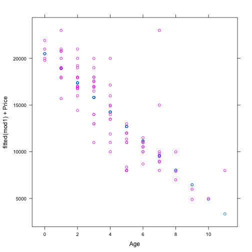

```r
xyplot(fitted(mod1) + Price ~ Age, data = cars)
```

It's a bit hard to see the model. Let's try another way of plotting it.

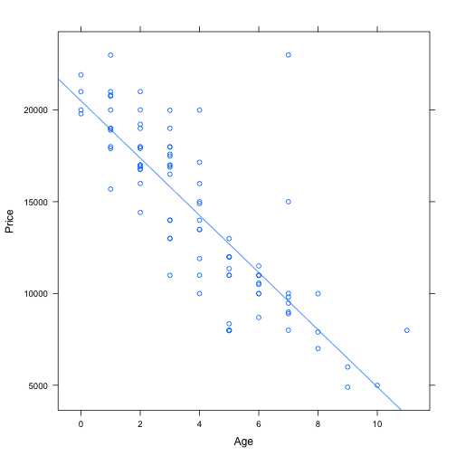

```r
f1 = makeFun(mod1)
plotPoints(Price ~ Age, data = cars)
plotFun(f1(Age) ~ Age, add = TRUE)
```

How much the price goes down with a year depends on how old the car is, but you can get the rate from the derivative of the function. Let's evaluate that derivative for an 8-year old car with 50,000 miles:

```r
f1 = makeFun(mod1)
df1 = D(f1(Age) ~ Age)
df1(Age = 8)
```

```
##     1
## -1559
```

Or, since I'm really thinking about a 1-year difference:

```r
f1(Age = c(9, 8), Mileage = 50000)
```

```
##    1    2
## 6465 8023
```

Take the difference. QUESTION: How come I get the same answer for the finite-difference and the derivative?

But let's consider mod4

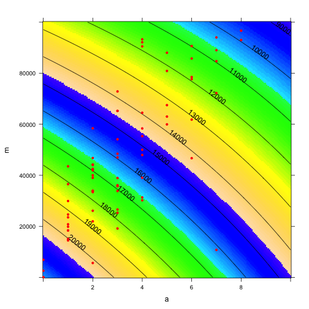

```r
f4 = makeFun(mod4)
plotFun(f4(Age = a, Mileage = m) ~ a & m, a.lim = c(0, 10), m.lim = c(0, 1e+05),
    levels = 1000 * (1:20), npts = 200)
plotPoints(Mileage ~ Age, data = cars, add = TRUE, pch = 20, col = "red")
```

Examine the change as age goes up by one year. Should I hold mileage constant or should I let the mileage change with age in the typical way?

Here's the same question another way: Do I want to compare cars with different mileages and different ages, or do I want to compare cares with different ages and the same mileage.

Calculating the partial derivative or partial change:

- Take a finite-difference approach

```r
f4(Age = c(8, 9), Mileage = 50000)
```

```
##     1     2
## 12815 12238
```

- Use partial derivatives

```r
df4da = D(f4(Age = Age, Mileage = Mileage) ~ Age)
df4da(Age = 8, Mileage = 50000)
```

```
##    1
## -577
```

- Do it analytically, using the coefficients to construct the model polynomial.

### Review of Partial Derivatives

Relate to the two-variable polynomial: \( f(x,y) = a_0 + a_1 x + a_2 y + a3 x y + ... \)

Relate to the three-variable polynomial.

- Calculation from model function by evaluating at nearby points

### Real-world examples

- Insurance example: Should we pay people not to be on the College's health plan?
- NGOs and development aid: Speaker Christie Hansen talked about how donors for health funding in Kenya ended up funding other activities as the government moved money away from health toward agriculture, etc.
- Merit aid. Will it reduce net tuition or increase it. Depends on whether we substantially change the yield.

Car data: work with the two-dimensional graphs